# Collect flow data for chimeric constructs in new background with standardized protocol

Bin He

22 mar 2022 (updated 04/04/22)

```r
require(tidyverse)
require(flowCore)
require(flowClust)
require(openCyto)
require(ggcyto)
require(cowplot)
```

# Data

*Plate design*

See `20220322-sample-list.txt`

| **Row \ Col** | **1** | **2-4** | **5** | **6-8** | **9** | **10-12** |
| --- | --- | --- | --- | --- | --- | --- |
| **A** | P | 194-555 | P | 209-373 | P | 230-555 |
| **B** | B | 194-373 | N | 209-555 | H2 | 230-373 |
| **C** | P | 211-555 | P | 218-373 | P | 232-555 |
| **D** | H1 | 211-373 | B | 218-555 | N | 232-373 |
| **E** | P | 213-555 | P | 220-373 | P | 234-555 |
| **F** | H2 | 213-373 | H1 | 220-555 | B | 234-373 |
| **G** | P | 215-555 | P | 221-373 | P | 235-555 |
| **H** | N | 215-373 | H2 | 221-555 | H1 | 235-373 |

B: blank wells to detect contamination during growth and control for media background fluorescence

N: negative control cells for estimating cell background fluorescence (yH156)

H1: host yH555 (with Pho2) without Pho4 plasmids, to estimate baseline RFP reporter levels

H2: host yH373 (without Pho2) without Pho4 plasmids, to estimate baseline RFP reporter levels

# Analysis

## Import data and edit the meta data

import the data from the RDSS (just once) and then write it to the local disk

Simplify the sample names

```r
# import the longest substring function from the PTXQC package (https://rdrr.io/cran/PTXQC/man/LCSn.html)
source("../../script/20220326-simplify-names-subroutine.R")
oriNames <- sampleNames(fs)
shortNames <- simplifyNames(oriNames) %>%
  gsub(".fcs","",.)
sampleNames(fs) <- shortNames
```

Metadata

```r
sample <- read.delim("20220322-sample-list.txt") %>%
  column_to_rownames(var = "file")
pData(fs) <- sample
```

## Gating

Let’s first define a gate and visualize it in a plot before adding it to a GatingSet.

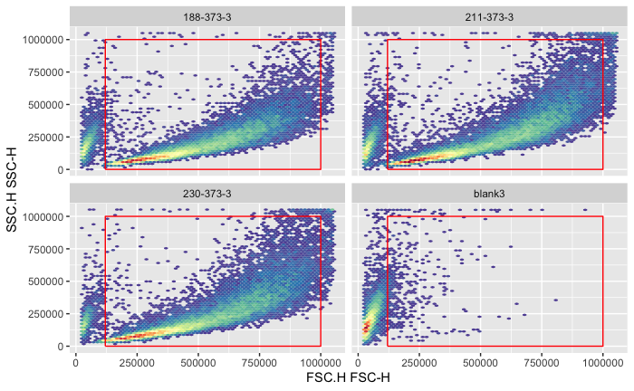

```r
test <- shortNames[c(3, 12*2+3, 12*5+3, 12*7+3)]
outlier.gate <- rectangleGate(filterId = "-outlier", "FSC.H" = c(1.2e5, 1e6), "SSC.H" = c(1e2, 1e6))
ggcyto(fs[test], aes(x = FSC.H, y = SSC.H), subset = "root") +
  geom_hex(bins = 64) + geom_gate(outlier.gate) + facet_wrap(~name, ncol = 2)# + ggcyto_par_set(limits = "instrument")
```

Add this gate to the GatingSet

```r
gs <- GatingSet(fs) # create a GatingSet
gs_pop_add(gs, outlier.gate, parent = "root")
```

```
[1] 2
```

```r
recompute(gs)
```

```
done!
```

### Singlet

Next let’s remove multiplets on FSC.H vs FSC.W. To do this, we could either manually set up a polygon gate, or use the automatic clustering function provided by the `flowClust` package. Note that in the original implementation, the `flowClust()` function or the `tmixFilter()` version that was supposed to allow for integration with the `flowCore` package, both were designed with different downstream actions in mind than what I want to do here (visualize with `ggcyto() + geom_gate()`). The `openCyto` package written by the same group of authors who created `flowClust` and `ggcyto` has a helper function to make this possible. See [this post](https://support.bioconductor.org/p/96945/) for a discussion on alternative ways to achieve this.

*Update* switch to a polygon gate as the clustering is not working well. *Update 2022/03/26* skip the singlet gate altogether

### PHO5-mCherry induction

When I plotted the singlet events on GFP-RFP 2d space, I noticed a few samples that show more than one population of cells, where the main population appeared to be “induced” while one or more subpopulations are less or not induced. While the biological reasons behind require further investigation and may be very interesting (heterogeneity), for this analysis we will use flowClust to identify the main population and move forward.

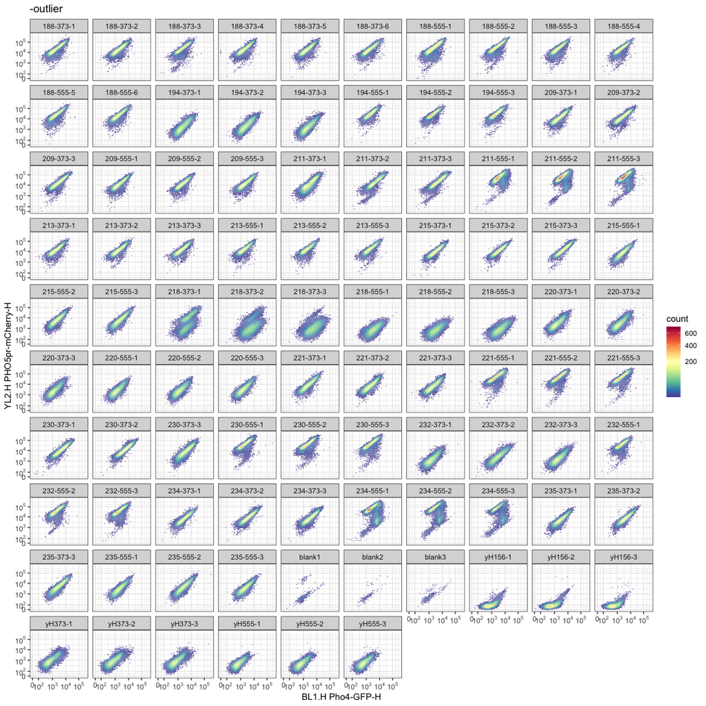

```r
ggcyto(gs, aes(x = BL1.H, y = YL2.H), subset = "-outlier") + geom_hex(bins = 64) +
  facet_wrap(~name, ncol = 10) + scale_x_logicle() + scale_y_logicle() + theme_bw()
```

> Be careful when working with the GatingSet and GatingHierarchy objects – these are strictly reference classes, meaning that most of the operations work by pointers and the operations will change the underlying data. For example, the first line of the code below (commented out) obtains a pointer to the underlying data rather than making a copy of that data. any operations on it will change the original data as a result.

```r
#ex <- gs_pop_get_data(gs, "singlet")[[1]]
ex <- fs[["234-555-1"]]
#lgcl <- estimateLogicle(ex, channels = c("BL1.H", "YL2.H"))
lgcl <- logicleTransform("induction")
# set cluster gate parameters
k = 1; q = 0.9
# end setting
ex <- transform(ex, lgBL1.H = lgcl(`BL1.H`), lgYL2.H = lgcl(`YL2.H`))
fluo.gate <- gate_flowclust_2d(ex, "lgBL1.H", "lgYL2.H", K = k, quantile = q)
```

```
The prior specification has no effect when usePrior=no
Using the serial version of flowClust
```

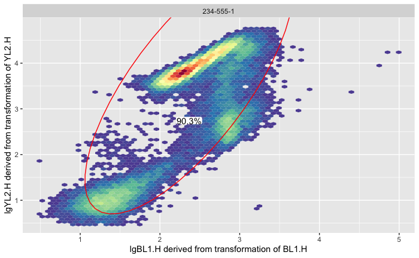

```r
ggcyto(ex, aes(x = lgBL1.H, y = lgYL2.H)) + geom_hex(bins = 64) + geom_gate(fluo.gate) + geom_stats()# + scale_x_logicle() + scale_y_logicle()
```

Even though flowClust is supposed to perform its own transformation (modified Box-Cox), empirically I found the clustering seem to work better on logicle transformed data for the two fluorescent channels. Therefore I’m transforming the underlying data of the GatingSet. Note that it seems to be difficult to “create new parameters” to store the transformed data, while keeping the original data intact. Instead, the transformation functions constructed using the constructor `logicle_trans()` stores the inverse transformation functions, which can be used to perform the inverse transformation when needed. Followed the manual for GatingSet [here](https://www.bioconductor.org/packages/devel/bioc/vignettes/flowWorkspace/inst/doc/flowWorkspace-Introduction.html#03_GatingHierarchy)

```r
lgcl <- logicle_trans()
transList <- transformerList(c(lgBL1.H = "BL1.H", lgclYL2.H = "YL2.H"), lgcl)
transform(gs, transList)
```

```
A GatingSet with 96 samples
```

> to obtain the original data, use `gs_pop_get_data(gs[[1]], inverse.transform = TRUE)`

Now we can do the flowClust gating

```r
dat <- gs_pop_get_data(gs, "-outlier") # get parent data
inductionGate <- fsApply(dat, function(fr){
  k1 = ifelse(grepl("234-555",identifier(fr)), 2, k)
  openCyto::gate_flowclust_2d(fr, "BL1.H", "YL2.H", K = k1, quantile = q)
})
gs_pop_add(gs, inductionGate, parent = "-outlier", name = "induction")
recompute(gs)
```

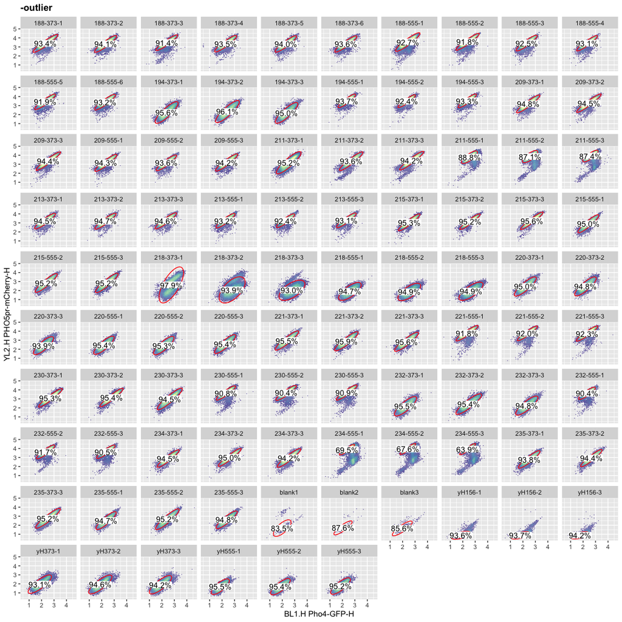

```r
ggcyto(gs, aes(x = BL1.H, y = YL2.H), subset = "-outlier") + geom_hex(bins = 64) + geom_gate("induction") + geom_stats() +
  facet_wrap(~name, ncol = 10)# + scale_x_logicle() + scale_y_logicle()
```

Notice that 218-373 showed more than one population and there is difference among the biological replicates. Let’s see if we can manually fix this.

```r
newGate <- list()
newGate[["218-373-1"]] = gate_flowclust_2d(dat[["218-373-1"]], "BL1.H", "YL2.H", K = 2, quantile = q, target = c(2.5,2))
```

```
The prior specification has no effect when usePrior=no
Using the serial version of flowClust
```

```r
newGate[["218-373-2"]] = gate_flowclust_2d(dat[["218-373-2"]], "BL1.H", "YL2.H", K = 2, quantile = q, target = c(2.5,2))
```

```
The prior specification has no effect when usePrior=no
Using the serial version of flowClust
```

```r
newGate[["218-373-3"]] = gate_flowclust_2d(dat[["218-373-3"]], "BL1.H", "YL2.H", K = 1, quantile = q, target = c(2.5,2))
```

```
The prior specification has no effect when usePrior=no
Using the serial version of flowClust
```

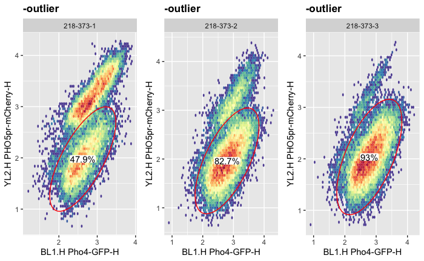

```r
p1 <- ggcyto(gs[["218-373-1"]], aes(x = BL1.H, y = YL2.H), subset = "-outlier") + geom_hex(bins = 64) +
  geom_gate(newGate[["218-373-1"]]) + geom_stats()
p2 <- ggcyto(gs[["218-373-2"]], aes(x = BL1.H, y = YL2.H), subset = "-outlier") + geom_hex(bins = 64) +
  geom_gate(newGate[["218-373-2"]]) + geom_stats()
p3 <- ggcyto(gs[["218-373-3"]], aes(x = BL1.H, y = YL2.H), subset = "-outlier") + geom_hex(bins = 64) +
  geom_gate(newGate[["218-373-3"]]) + geom_stats()
plot_grid(as.ggplot(p1), as.ggplot(p2), as.ggplot(p3), ncol = 3)
```

```r
# update the inductionGate object
gs_pop_set_gate(gs[grep("218-373", sampleNames(gs), value = TRUE)], "induction", newGate)
```

```r
recompute(gs[grep("218-373", sampleNames(gs), value = TRUE)], "induction")
```

```
done!
```

## Normalization

Because the amount of fluorescence scales with cell size, comparing the median of each sample would only be valid if the cell size distribution is approximately the same across samples. Is that the case?

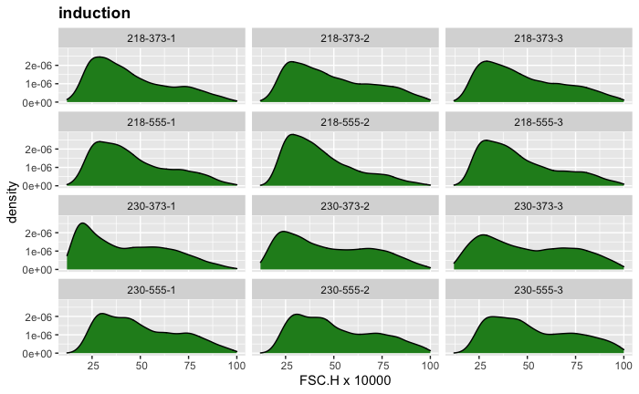

```r
mult_format <- function() {
     function(x) format(x/10000,digits = 2)
}
ggcyto(gs[[grep("218|230", sampleNames(fs), value = T)]], aes(x = FSC.H), subset = "induction") + geom_density(fill = "forestgreen") +
  scale_x_continuous(labels = mult_format(), name = "FSC.H x 10000") +
  facet_wrap(~name, ncol = 3)
```

Brian Metzger and colleagues proposed a simple correction in their 2015 paper. The intuition behind this method is that FSC is proportional to the max 2d projection (area) of a cell, and thus FSC^(3/2) should be roughly proportional to the volume. By contrast, the fluorescent channels should be the cumulative intensity from the whole cell. Therefore dividing FP intensity by FSC^(3/2) should effectively remove the variation due to cell size difference. He did say that the Wittkopp lab later switched to a different method based on PCA and rotations. After reading those papers, I thought the simpler one will suffice for us.

Test normalization formula

```r
# get population data
fs.out <- gs_pop_get_data(gs, y = "induction", inverse.transform = TRUE) # get the inverse transformed data
# come up with an approximate FSC.H value for an average event to be used a scalar for the next step
mfsc <- 5e5 # based on the mode of the median of FSC.H from all samples
# fs.out is of the cytoframe class, which is a reference class. need to convert to flowframe for transformation
# https://www.bioconductor.org/packages/devel/bioc/vignettes/flowWorkspace/inst/doc/flowWorkspace-Introduction.html
exponent <- 1.5
# ex <- cytoframe_to_flowFrame(fs.out[["A9"]]) %>%
#   transform(nFSC = FSC.H/mfsc) %>%
#   transform(nGFP = BL1.H/nFSC^(exponent), nRFP = YL2.H/nFSC^(exponent))

ex <- cytoset_to_flowSet(fs.out) %>%
  transform(nFSC = FSC.H/mfsc) %>%
  transform(nGFP = BL1.H/nFSC^(exponent), nRFP = YL2.H/nFSC^(exponent))
```

plot the examples

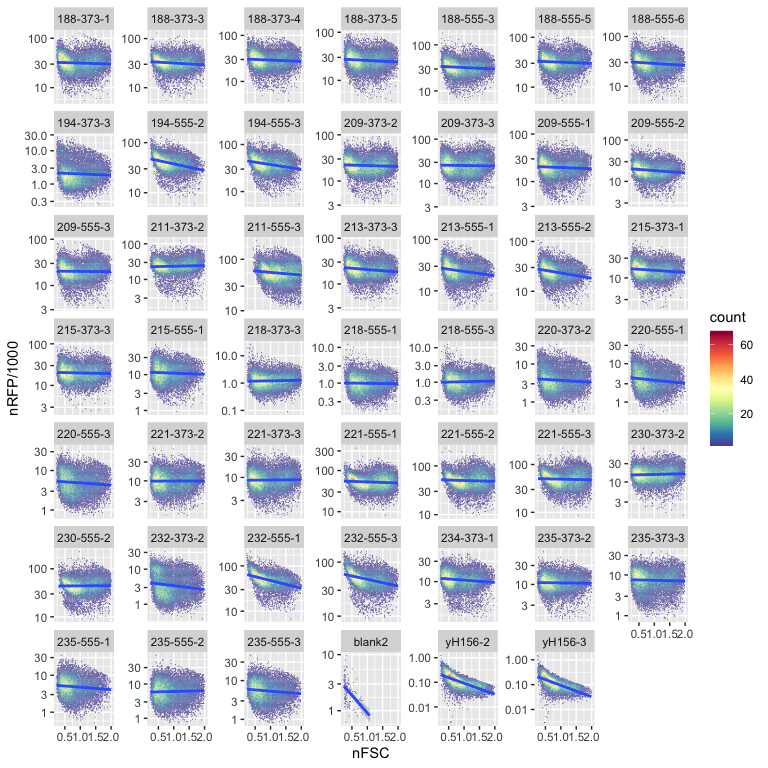

```r
ggplot(ex[sample(1:96, 48)], aes(x = nFSC, y = nRFP/1e3)) + geom_hex(bins = 64) + scale_y_log10() + stat_smooth(method = "lm") +
  scale_fill_gradientn(colours = rev(RColorBrewer::brewer.pal(11, "Spectral"))) + facet_wrap(~name, scales = "free_y")
```

```r
# calculate ratio
norm.data <- fsApply(fs.out, function(cf) {
  cf <- cbind(cf,
              nRFP = cf[,"YL2.H"] / (cf[, "FSC.H"]/mfsc)^(exponent),
              nGFP = cf[,"BL1.H"] / (cf[, "FSC.H"]/mfsc)^(exponent))
  apply(cf[, c("FSC.H", "BL1.H", "YL2.H", "nGFP", "nRFP")], 2, median)
  }, use.exprs = TRUE) %>%
  as_tibble(rownames = "name")  %>%
  mutate(across(BL1.H:nRFP, ~ round(.x, 1)))
```

# Output

The goal is to export the gated events and calculate the RFP/GFP and take the median, which will be used in downstream analyses.

Get the population stats

```r
stats <- gs_pop_get_stats(gs) %>%
  as_tibble() %>%
  mutate(pop = gsub(".*/", "", pop), pop = gsub("-outlier", "cells", pop)) %>%
  pivot_wider(names_from = pop, names_prefix = "n_", values_from = count)
```

Export the data

```r
# pull all info together in a single tibble
final <- left_join(as_tibble(pData(fs)), stats, by = c("name" = "sample")) %>%
  left_join(norm.data, by = "name")
write_tsv(final, "20220327-gated-median-out.txt")
```